# Auswertung_PVG

Patric Schubert

2025-07-11

# 1 Datei-Import und -preprocessing

PVG-Datei: Die Analyse basiert auf dem Datensatz MN.

## 1.1 Allgemeine Informationen (Rohdaten):

Die Daten umfassen **365** Tage im Zeitraum vom 2024-01-01 bis 2024-12-31. Es gibt 270 verschiedene Zugnummern im Datensatz. Die Anzahl unterschiedlicher Zugachsen beträgt 165.

## 1.2 Vorverarbeitung:

Die initiale Größe des Datensatzes betrug 27090. Nach erster Filterung (nur ein Wagenmeister war zuständig [anzWeitereMitarbeiter == 0], Mindestzuglänge größer als Null [abfahrtZugLaenge > 0], reguläre digitale Bearbeitung [bemerkung != ‘Abbruch’]) war diese 25005. Reduktion der PVG-Doubletten führte dann zu 9464 Wageneinträgen. Nach Zusammenfassung der Wageneinträge (initiale Einträge im PVG-System) zu Zügen betrug die Größe 6203. Eine finale Filterung (Mindestzuglänge von mindestens 10 Wagen [abfahrtZugFahrzeuge > 9], Die Mindestbegutachtungszeit durch Wagenmeister größer als 20 Minuten [begutachtungMinuten > 20]) ergab 5568 betrachtete Züge (Reduktion um weitere 635 Züge).

## 1.3 Allgemeine Informationen (gefilterte Daten):

Nach derFilterung beträgt der Zeitraum **365** Tage im Zeitraum vom 2024-01-01 bis 2024-12-31. Es gibt 168 verschiedene Zugnummern im gefilterten Datensatz. Die Anzahl unterschiedlicher Zugachsen beträgt 146.

## 1.4 Vergleich - Rohdaten vs. Gefilterte Daten:

Anzahl der Wagen pro Zug

|  | Minimum | Q1.25% | Median | Q3.75% | Maximum |
| --- | --- | --- | --- | --- | --- |
| Rohdaten | 0 | 19 | 27 | 34 | 49 |
| Gefiltert | 10 | 18 | 24 | 30 | 49 |

Länge der Wagen pro Zug

|  | Minimum | Q1.25% | Median | Q3.75% | Maximum |
| --- | --- | --- | --- | --- | --- |
| Rohdaten | 0 | 332 | 475.0 | 606.0 | 720 |
| Gefiltert | 121 | 321 | 431.5 | 555.2 | 720 |

# 2 Statistiken zum gefilterten Datensatz:

Das folgende Plot zeigt die Häufigkeit bearbeiteter Züge über den Zeitraum.

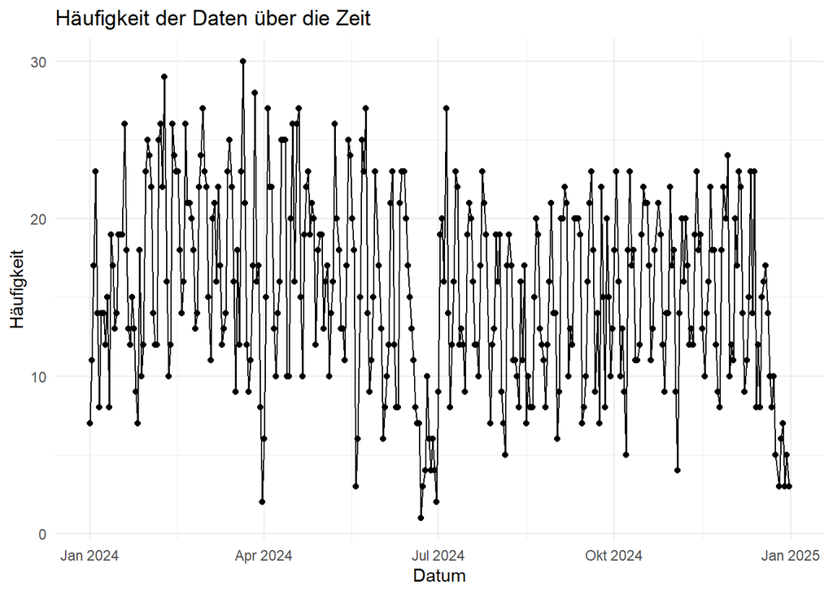

Eine Frequenzanalyse soll Periodizitäten im Datensaz aufzeigen.

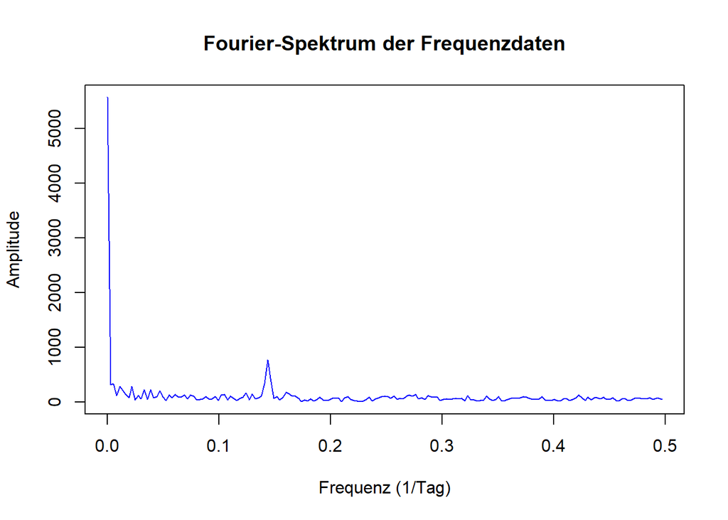

Die dominante Frequenz liegt bei 0.1436464 Zyklen pro Tag, die approximierte Periode bei 6.9615385 Tagen.

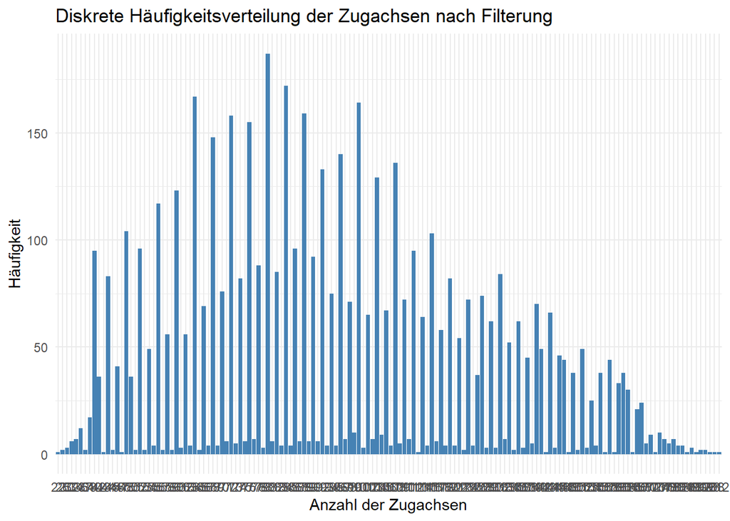

[interactive chart not shown]

Die Züge weisen im Median 0.3308458 (IQR:1) Schäden auf. Das obere Quartil ist 1, das untere Quartil ist 0. Im Folgenden sind diejenigen Züge gelistet, die nch dem Tukey-Kriterium (oberes Quartil plus 1,5fachen Interquartilabstand) viele Schäden aufwiesen.

|  | zugnummer | SchaedenproTag | absoluteAnzSchaeden | Tage |
| --- | --- | --- | --- | --- |
| 1 | 51607 | 3 | 3 | 1 |
| 2 | 51613 | 3.5 | 28 | 8 |
| 3 | 60387 | 4 | 8 | 2 |
| 4 | 68330 | 3 | 6 | 2 |
| 5 | 68371 | 2.666666666666667 | 8 | 3 |
| 6 | 68390 | 6 | 6 | 1 |
| 7 | 68391 | 4.666666666666667 | 14 | 3 |

## 2.1 Tagesverteilungen

Die nachfolgende Grafik zeigt die durchschnittliche Begutachtungszeit in Minuten (begutachtungMinuten) und die durchschnittliche Länge der Züge.

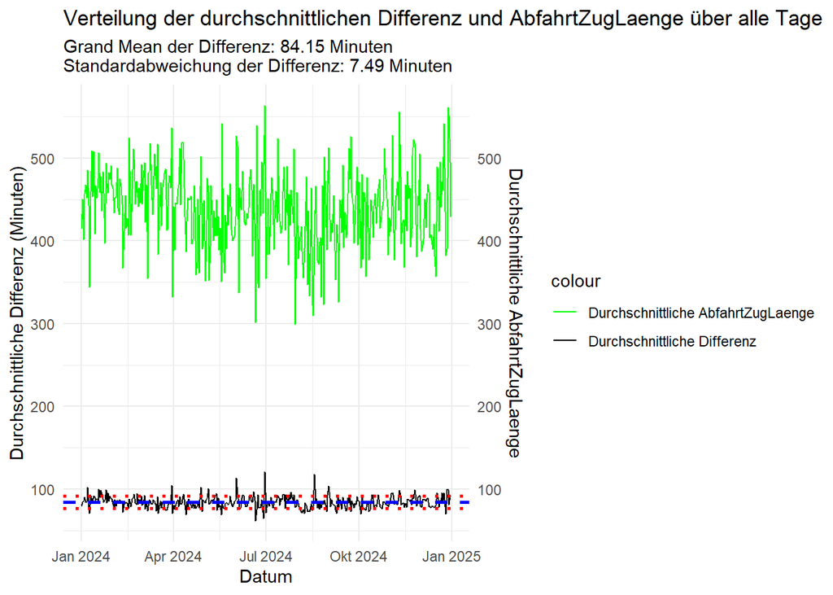

|  | tag | durchschnittlicheDifferenz | stabwDifferenz | durchschnittlicheAbfahrtZugLaenge | stabwAbfahrtZugLaenge | durchschnittlicheWegezeit | durchschnittlicheAnzSchaeden | anzahlZuege |
| --- | --- | --- | --- | --- | --- | --- | --- | --- |
| 1 | 2024-01-01 | 80.14 | 15.87 | 414.71 | 140.33 | 6.43 | 1.14 | 7 |
| 2 | 2024-01-02 | 84.55 | 29.96 | 450.55 | 149.16 | 2.73 | 0.27 | 11 |
| 3 | 2024-01-03 | 86.24 | 28.89 | 401.59 | 137.48 | 2.65 | 0.59 | 17 |
| 4 | 2024-01-04 | 90.57 | 28.07 | 456.83 | 146.41 | 2.61 | 1 | 23 |
| 5 | 2024-01-05 | 84.14 | 22.31 | 468.14 | 186.74 | 2.14 | 0.64 | 14 |
| 6 | 2024-01-06 | 85 | 25.3 | 451.75 | 184.47 | 0 | 1.12 | 8 |
| 7 | 2024-01-07 | 102.43 | 27.7 | 485.5 | 170.36 | 1.07 | 1.57 | 14 |
| 8 | 2024-01-08 | 78.86 | 36.73 | 442.86 | 176.48 | 2.86 | 1.29 | 14 |
| 9 | 2024-01-09 | 70.42 | 23.48 | 344.17 | 135.34 | 0 | 0.5 | 12 |
| 10 | 2024-01-10 | 91.67 | 27.49 | 459.27 | 143.54 | 1 | 0.27 | 15 |

[output cut: 352 more lines]

## 2.2 Zusammenhang der Begutachtungszeit zu weiteren Variablen

Für das nächste Plot wurden die Daten Begutachtungszeit, Zuglänge und zusätzlich Wegezeiten, Anzahl der Schäden normiert um wechselseitige Abhängigkeiten zu evaluieren.

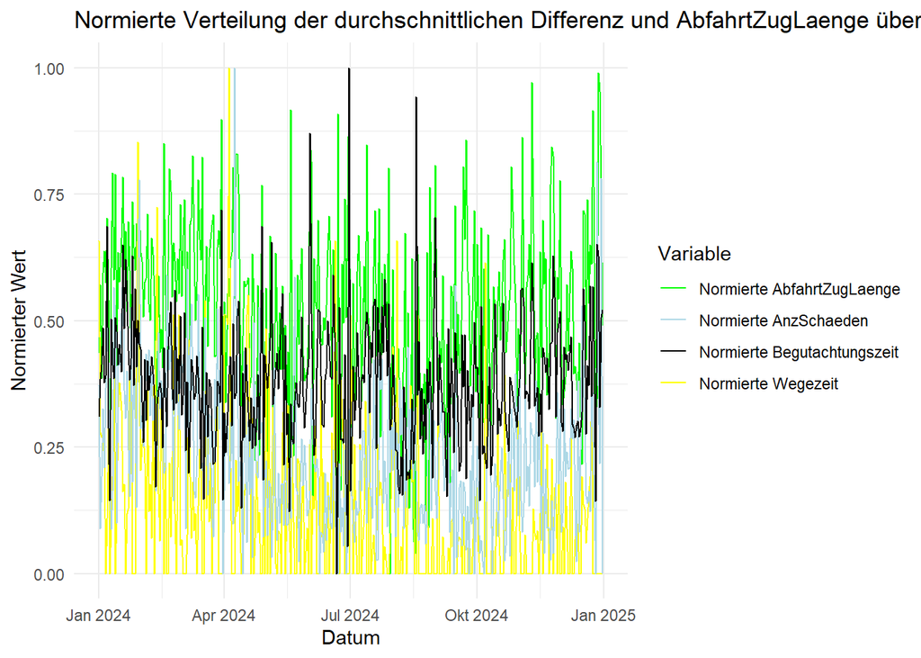

Es ergeben sich folgende Korrelationen: r=0.5 (Korrelation zwischen Begutachtungszeit und Zuglänge), r=-0.1 (Korrelation zwischen Begutachtungszeit und Wegezeit) und r=0.2 (Korrelation zwischen Begutachtungszeit und der Anzahl der Schäden).

## 2.3 Analyse der Begutachtungszeit

Die Begutachtungszeit (1. in Minuten pro Meter und 2. in Minuten pro Achse) wird im folgenden pro Zug analysiert.

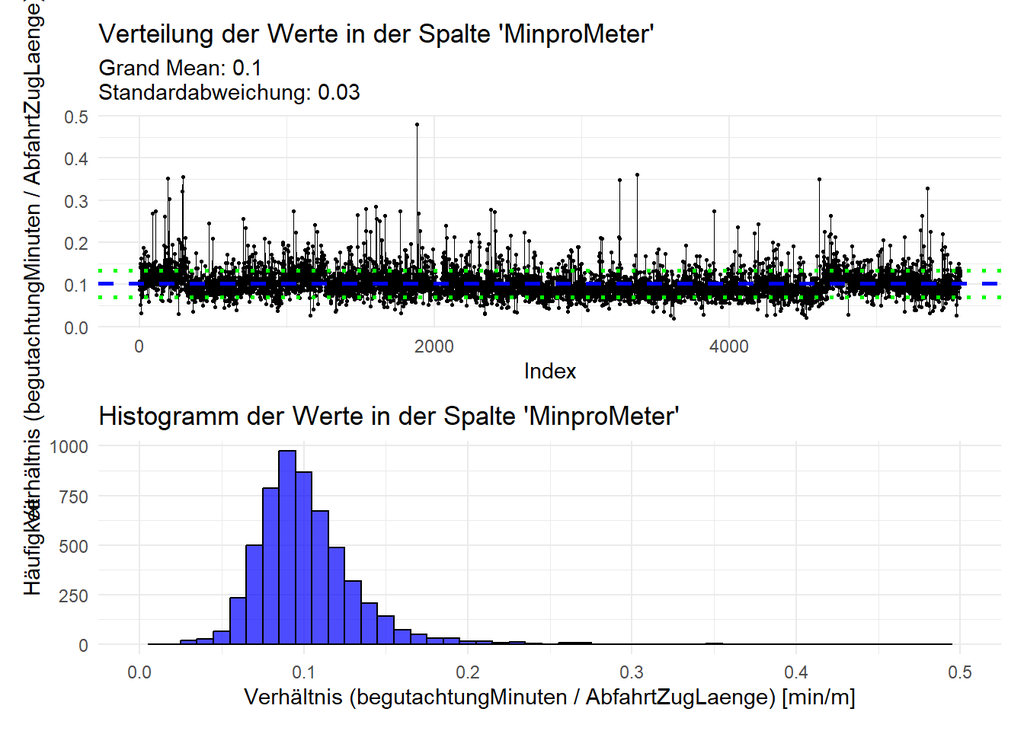

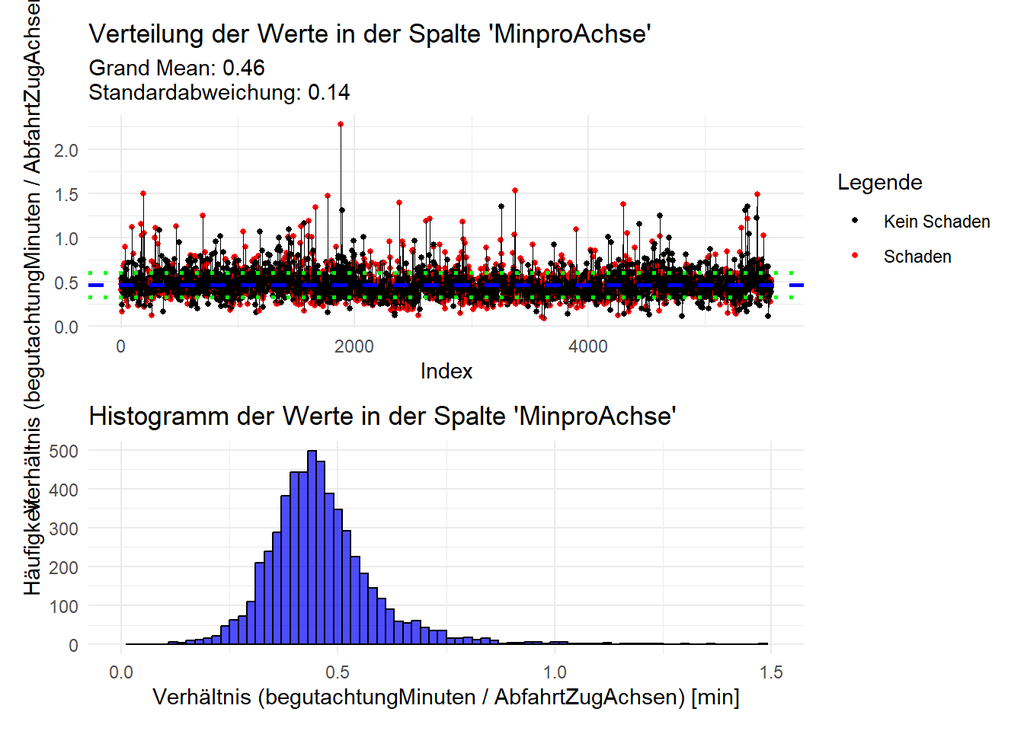

Im Durchschnitt liegt die Begutachtungszeit bei M=0.1 Minuten pro Meter (SD= 0.03) oder M=0.46 Minuten pro Achse (SD= 0.14).

## 2.4 Länge von Zügen

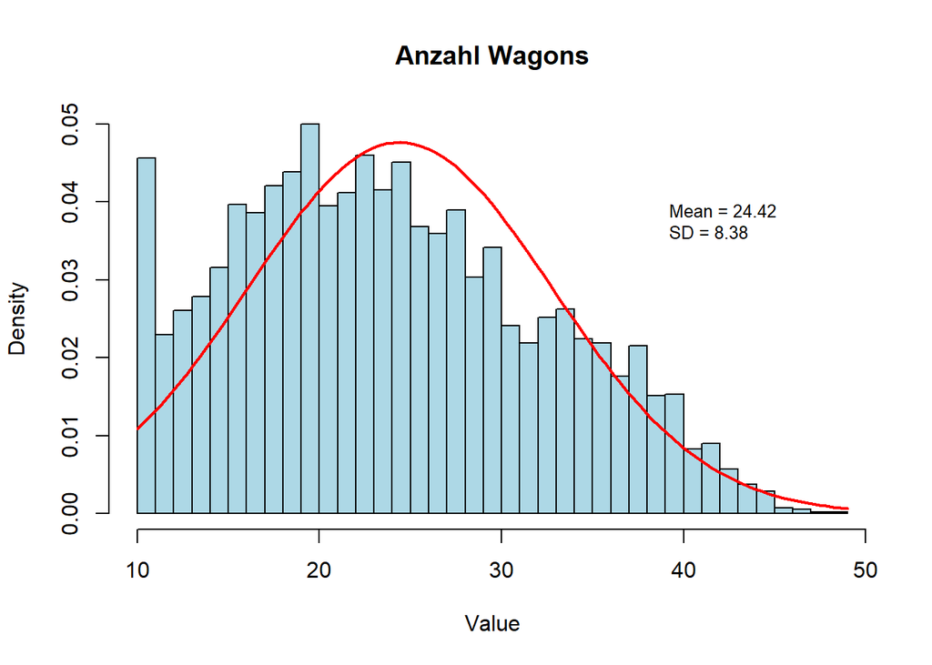

Die Anzahl der Güterwagen pro Zug wird als normalverteilte Zufallsvariable behandelt (rote Linie). Es ergibt sich ein Mittelwert von 24.42 bei einer Standardabweichung von 8.38. Die Länge von Zügen ist annahmegemäß betaverteilt mit den Form-Parametern Alpha und Beta. Im ersten Plot ist die Länge der Züge auf [0,1] normiert dargestellt. Das zweite Plot rücktransformiert auf die tatsächlichen Längen in Meter.

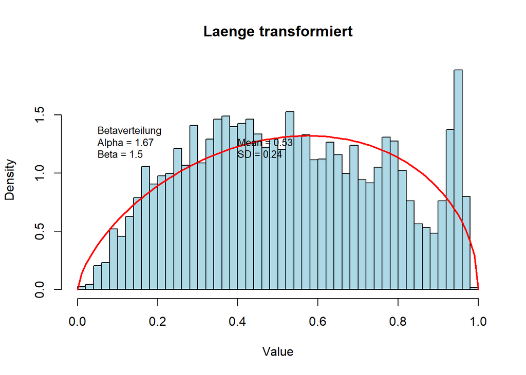

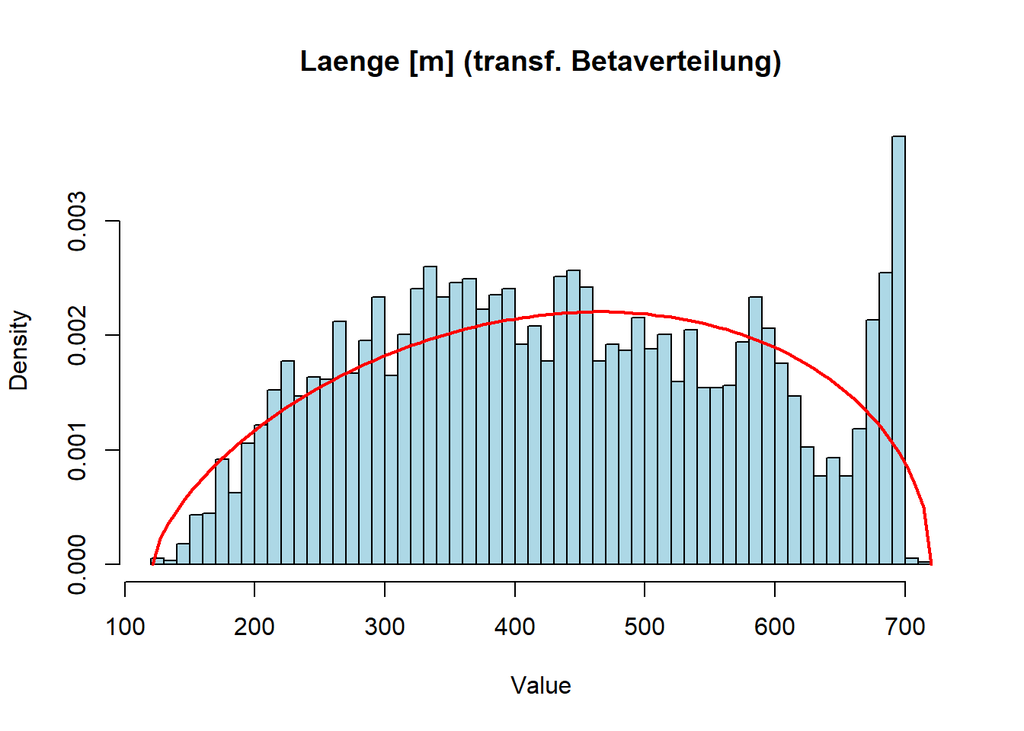

## 2.5 Frequenzierung der Züge pro Tag

Die Frequenzierung wird wegen tageszeitlichen Schwankungen durch eine (zweifach) gemixte Normalverteilung beschrieben.

```
## summary of normalmixEM object:
##           comp 1    comp 2
## lambda  0.602844  0.397156
## mu     11.708848 20.955491
## sigma   4.237758  3.401934
## loglik at estimate:  -1152.741
```

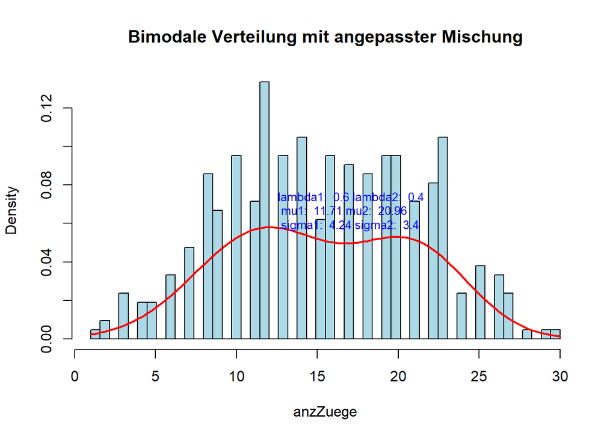

Es ergeben sich folgende Quantile: 10%: 180, 25%: 130.9090909, 50%: 96, 75%: 72, 90%: 62.6086957, 100%: 48.

Separat über die Wochentage ergibt sich folgende Schätzung:

|  | Wochentag | lambda1 | lambda2 | mu1 | mu2 | sigma1 | sigma2 |
| --- | --- | --- | --- | --- | --- | --- | --- |
| 1 | Montag | 0.13 | 0.87 | 6.38 | 11.77 | 1.51 | 3.27 |
| 2 | Dienstag | 0.04 | 0.96 | 3.96 | 17.36 | 1 | 4.03 |
| 3 | Mittwoch | 0.41 | 0.59 | 16.56 | 22.84 | 4.87 | 2.2 |
| 4 | Donnerstag | 0.12 | 0.88 | 6.51 | 20.38 | 2.27 | 3.55 |
| 5 | Freitag | 0.09 | 0.91 | 6.6 | 19.68 | 0.49 | 4.28 |
| 6 | Samstag | 0.08 | 0.92 | 12.39 | 12.84 | 0.53 | 4.24 |
| 7 | Sonntag | 0.89 | 0.11 | 10.53 | 2.79 | 2.36 | 0.66 |

## 2.6 Wahrscheinlichkeit von Schäden

Schäden werden typischerweise durch eine Weibullverteilung (mit zwei Formparametern) modelliert.

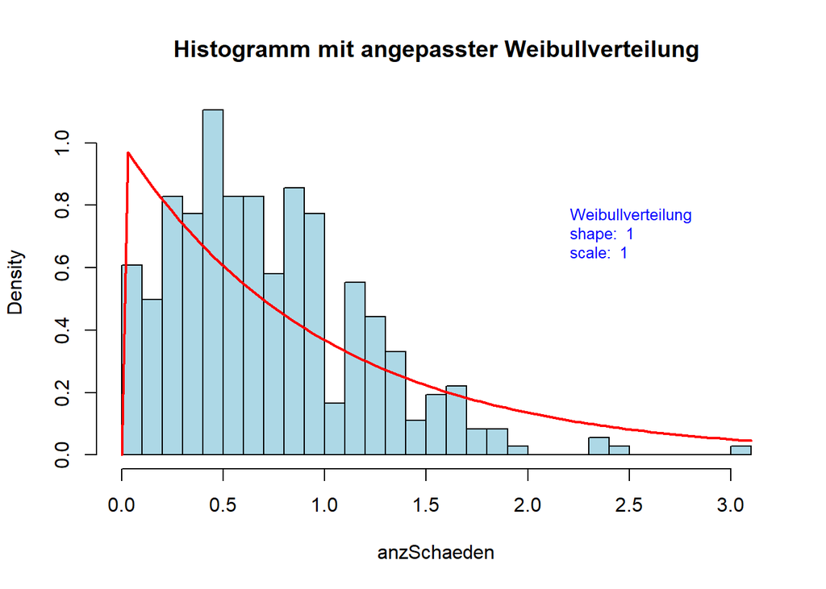

Es ergeben sich folgende Quantile für die Anzahl der Schäden: 10%: 0.2, 25%: 0.3856838, 50%: 0.6339713, 75%: 1, 90%: 1.359.

## 2.7 Zusätzliche Begutachtungszeit durch Schäden

Die durchschnittliche Begutachtungszeit ohne Schaden ist M1 = 80.58 (SD=24.97). Die durchschnittliche Begutachtungszeit für mindestens einen Schaden ist M2 = 91.58 (SD=26.35). Aus der mittleren Anzahl der Schäden (M = 2.49) berechnet man den Quotienten (M1 - M2)/M = 4.42.

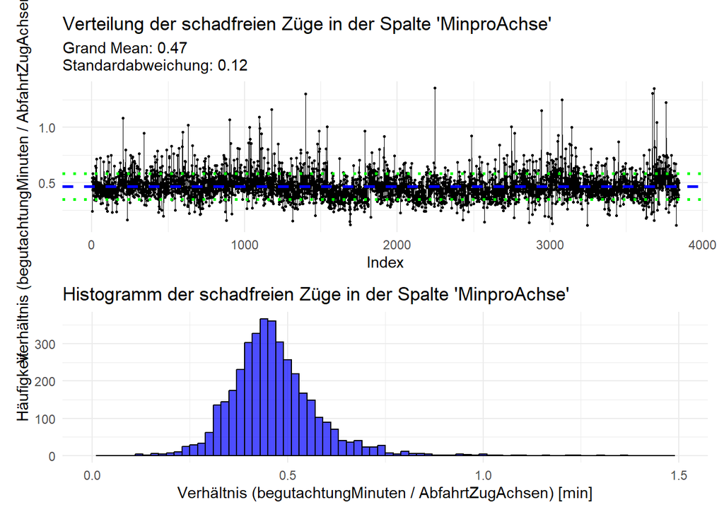

## 2.8 Analyse nach Schadklassen

[interactive chart not shown]

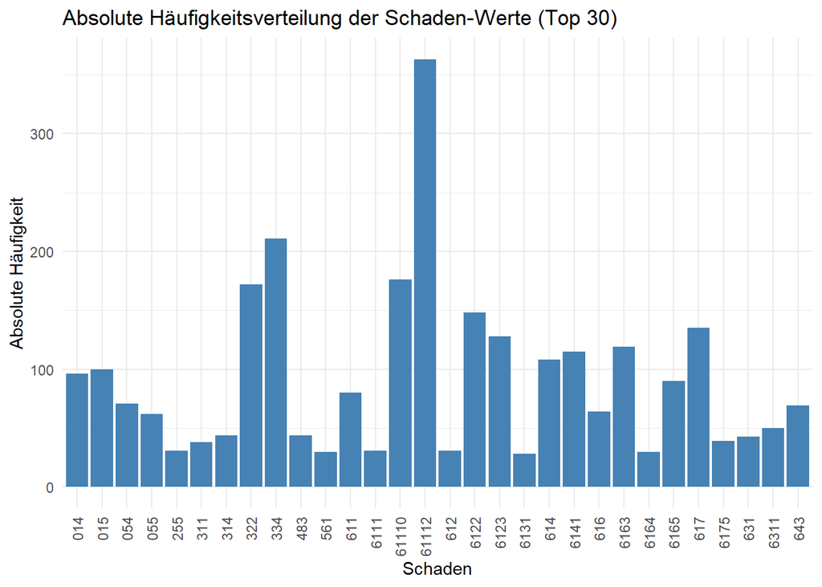